# AUTHORS:

- Tal Alfi
- Ziv Friza
- Oleg Belochitzky

A general explanation of our data set:  
The data set describes a bank's marketing campaign - which is based on making calls to customers.  
the last column ('class') describes if at the end of the campign, the client subscribed a term deposit.  
there are 15 different columns on out data set, and 1 column to tell if the person has subscribed to the term deposit.  
the columns are:

1. age.
2. job : type of job : admin,unknown,unemployed,management,housemaid,entrepreneur,student, blue-collar,self-employed,retired,technician,services.
3. marital : marital status: married,divorced,single, widowed.
4. education: unknown,secondary,primary,tertiary.
5. default: has credit in default? - 'yes' or 'no'.
6. balance: average yearly balance, in euros.
7. housing: has housing loan? - 'yes' or 'no'.
8. loan: has personal loan? - 'yes' or 'no'.
9. contact: contact communication type: unknown, telephone, cellular.
10. day: last contact day of the month.
11. month: last contact month of year jan, feb, mar, ..., nov , dec.
12. duration: last contact duration, in seconds.
13. campaign: number of contacts performed during this campaign and for this client.
14. pdays: number of days that passed by after the client was last contacted from a previous campaign.
15. previous: number of contacts performed before this campaign and for this client.
16. poutcome: outcome of the previous marketing campaign : unknown,other,failure,success.

#### first, we will import the following libreries

```python
import pandas as pd
import numpy as np
import seaborn as sns
import matplotlib.pyplot as plt
```

we will load the traning file on which we will perform the EDA

```python
data = pd.read_csv("files/train.csv")
```

lets have a look at our data frame first:

```python
data.head()
```

|  | age | job | marital | education | default | balance | housing | loan | contact | day | month | duration | campaign | previous | poutcome | class |
| --- | --- | --- | --- | --- | --- | --- | --- | --- | --- | --- | --- | --- | --- | --- | --- | --- |
| 0 | 58 | management | married | tertiary | no | 2143.0 | yes | no | unknown | 5 | may | 261.0 | 1 | 0 | unknown | no |
| 1 | 44 | technician | single | secondary | no | 29.0 | yes | no | unknown | 5 | may | 151.0 | 1 | 0 | unknown | no |
| 2 | 33 | entrepreneur | married | secondary | no | 2.0 | yes | yes | unknown | 5 | may | 76.0 | 1 | 0 | unknown | no |
| 3 | 47 | blue-collar | married | unknown | no | 1506.0 | yes | no | unknown | 5 | may | 92.0 | 1 | 0 | unknown | no |
| 4 | 33 | unknown | single | unknown | no | 1.0 | no | no | unknown | 5 | may | 198.0 | 1 | 0 | unknown | no |

```python
data.tail()
```

|  | age | job | marital | education | default | balance | housing | loan | contact | day | month | duration | campaign | previous | poutcome | class |
| --- | --- | --- | --- | --- | --- | --- | --- | --- | --- | --- | --- | --- | --- | --- | --- | --- |
| 42175 | 60 | self-employed | married | tertiary | no | 10861.0 | no | no | cellular | 9 | nov | 98.0 | 1 | 2 | failure | yes |
| 42176 | 64 | entrepreneur | married | tertiary | no | 2331.0 | no | no | telephone | 9 | nov | 201.0 | 1 | 0 | unknown | yes |
| 42177 | 34 | admin. | married | secondary | no | 2374.0 | yes | no | cellular | 9 | nov | 161.0 | 1 | 2 | failure | yes |
| 42178 | 35 | management | single | tertiary | no | 1228.0 | no | no | cellular | 9 | nov | 696.0 | 2 | 12 | failure | yes |
| 42179 | 53 | management | married | tertiary | no | 1356.0 | yes | no | cellular | 9 | nov | 371.0 | 2 | 4 | failure | no |

```python
data.shape
```

```
(42180, 16)
```

```python
data.nunique()
# Notice that some of the columns has many values - thats because they are numical columns.
```

```
age            75
job            12
marital         3
education       4
default         2
balance      7051
housing         2
loan            2
contact         4
day            31
month          14
duration     1555
campaign       48
previous       37
poutcome        5
class           2
dtype: int64
```

we would like to see if our data set is balanced.

```python
data['class'].value_counts()
```

```
no     38455
yes     3725
Name: class, dtype: int64
```

we can immediately see that our data set isn't balanced, because the classification column has 91.1% values of no and 8.9% values of yes.

we will now calculate the percentage of the missing values

```python
#calculate the missing data
missing_data = pd.DataFrame({'total_missing': data.isnull().sum(), 'perc_missing': (data.isnull().sum()/len(data))*100})
missing_data
```

|  | total_missing | perc_missing |
| --- | --- | --- |
| age | 0 | 0.000000 |
| job | 0 | 0.000000 |
| marital | 0 | 0.000000 |
| education | 2 | 0.004742 |
| default | 0 | 0.000000 |
| balance | 5 | 0.011854 |
| housing | 3 | 0.007112 |
| loan | 1 | 0.002371 |
| contact | 7 | 0.016596 |
| day | 0 | 0.000000 |
| month | 0 | 0.000000 |
| duration | 11 | 0.026079 |
| campaign | 0 | 0.000000 |
| previous | 0 | 0.000000 |
| poutcome | 0 | 0.000000 |
| class | 0 | 0.000000 |

As we can notice, the amount of missing data is negligible.  
However, we will deal with it in the preprocessing of the data.  
for no we will just remove the nan values

```python
data.dropna(inplace=True)
```

we will now have a look at the statistical description of the numeric values, so that we will have a batter understanding of thier properties

to have a better sense of the outliers, lets have a look at the numerical quantitites of our dataset

```python
data.describe()
```

|  | age | balance | day | duration | campaign | previous |
| --- | --- | --- | --- | --- | --- | --- |
| count | 42156.000000 | 42156.000000 | 42156.000000 | 42156.000000 | 42156.000000 | 42156.000000 |
| mean | 40.736360 | 1322.082100 | 15.869817 | 255.439416 | 2.825742 | 0.450659 |
| std | 10.096543 | 2985.170663 | 8.301974 | 258.212349 | 3.176506 | 2.144005 |
| min | 18.000000 | -8019.000000 | 1.000000 | 0.000000 | 1.000000 | 0.000000 |
| 25% | 33.000000 | 61.000000 | 8.000000 | 101.000000 | 1.000000 | 0.000000 |
| 50% | 39.000000 | 425.000000 | 16.000000 | 176.000000 | 2.000000 | 0.000000 |
| 75% | 48.000000 | 1370.250000 | 21.000000 | 314.000000 | 3.000000 | 0.000000 |
| max | 95.000000 | 102127.000000 | 31.000000 | 4918.000000 | 63.000000 | 275.000000 |

from the table above, we can draw the following conclusions:

> the majority of the costumers were at the age : 40 , the youngest were 18 y.o and the oldest were 95 y.o

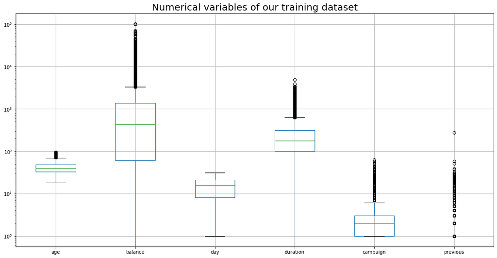

```python
num_cols = data.select_dtypes([np.number]).columns
plt.figure(figsize=(18,9))
plt.yscale("log")
data[num_cols].boxplot()
plt.title("Numerical variables of our training dataset", fontsize=20)
plt.show()
```

**notice** that we chose logarithmic growth for our plot y axis, so that we will be able to notice columns with smaller ranges of numerical data, and also columns with higher variables range.

from that plot, we can see that there is single maximum value which is exceptionals, and need to be removed. this value is 275 for the column previous.

we will now have a look at the correlation between all the numerical columns.

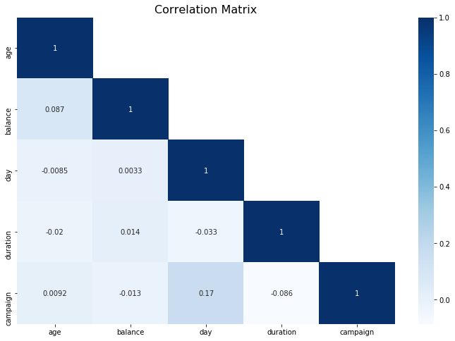

```python
fig = plt.figure(figsize=(12,8))
# cutting the last column because in the next In we will see more detailed
# colnclusions about the other columns and the classification column.
numeric_columns = data.select_dtypes(exclude="object").iloc[:, :-1]
corr_numeric = numeric_columns.corr()

np.tril(np.ones(corr_numeric.shape)).astype(np.bool)[0:5,0:5]
# we only want to present the lower tringle of the matrix (since it is symmetrical)

df_lt = corr_numeric.where(np.tril(np.ones(corr_numeric.shape)).astype(np.bool))
df_lt.iloc[0:5,0:3]


hmap=sns.heatmap(df_lt,cmap="Blues",yticklabels=corr_numeric.columns,annot=True)
plt.title("Correlation Matrix", fontsize=16)
plt.show()
```

since there is quite a bit correlation between day and campign , lets have a deeper look at them and lets see if there is also correlation between them and the 'class' column.

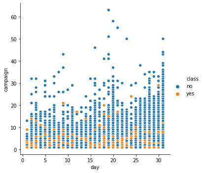

```python
sns.relplot(x='day',y='campaign',hue ='class',data=data)
```

Next, we would like to see if there is correlation between some columns to the classification columns.  
we would expect to see some correlation between the following columns to the 'class' column:

- education
1. age
2. campaign
3. previous
4. balance

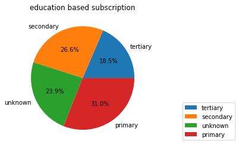

```python
labels = data['education'].unique()
lengths = []
for unique in labels:
    sd=data.loc[(data['education'] == unique)]
    len_of_unique = (len(data.loc[(data['education'] == unique)]))
    len_of_yes_for_unique = len(sd.loc[(data['class'] == 'yes')])
    div = len_of_unique/len_of_yes_for_unique
    lengths.append((div))

plt.title("education based subscription")
plt.pie(lengths,labels=labels,autopct='%1.1f%%')
plt.legend(loc='lower right', bbox_to_anchor=(1, 0, 0.7, 1))
plt.show()
```

we will now check the column 'age'.  
since this is a numeric column, we will use binning to see what are the ages of the peoples that subscribed.

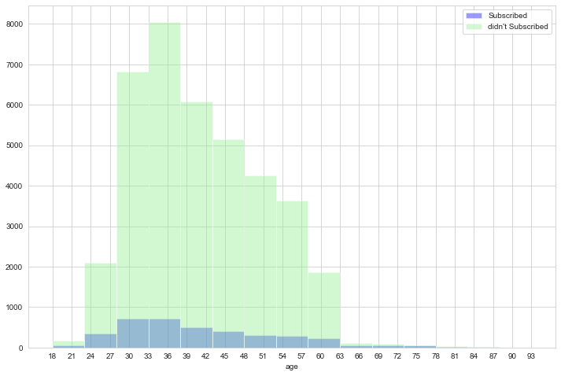

```python
fig = plt.figure(figsize=(12, 8))
maxx = max(data['age'])
minn = min(data['age'])
bins = range(minn,maxx, 5)
sns.set_style('whitegrid')
ax = sns.distplot(data.age[data['class']=='yes'],
              color='blue',  bins=bins,kde = False, label='Subscribed')
sns.distplot(data.age[data['class']=='no'],
         ax=ax,color='lightgreen',kde = False, bins=bins, label="didn't Subscribed")
plt.xticks([x for x in range(18,96,3)])
plt.legend()
plt.show()
```

This plot is a bit missleading , because at first sight we might assume that people in the age range of 28-45, tend to: either be a subscriber or not. However - the reason for that is - because they constitute the majority of the 'age' column.

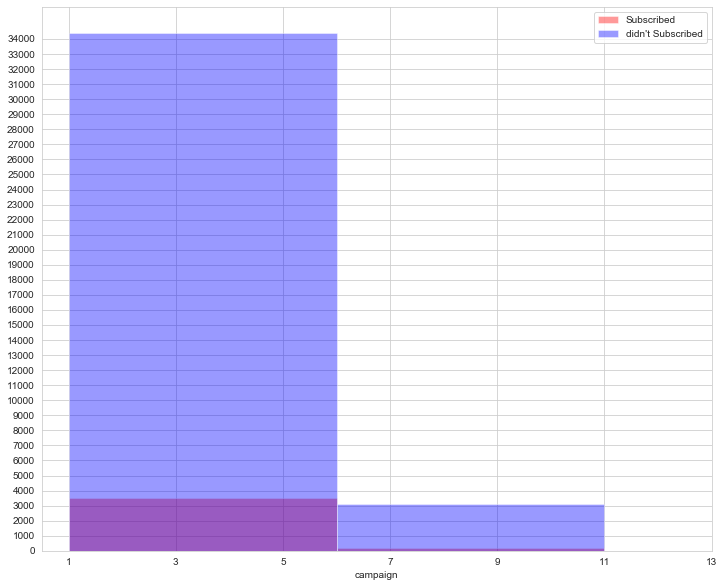

```python
fig = plt.figure(figsize=(12, 10))

modified_data= data.loc[data['campaign'] <15 ]
modified_data= modified_data.loc[modified_data['campaign'] >=0 ]

maxx = int(max(modified_data['campaign']))
minn = int(min(modified_data['campaign']))
bins = range(minn,maxx, 5)
sns.set_style('whitegrid')
ax = sns.distplot(modified_data.campaign[data['class']=='yes'],
               color='red',  bins=bins,kde = False, label='Subscribed')
sns.distplot(modified_data.campaign[data['class']=='no'],
         ax=ax,color='blue',kde = False, bins=bins, label="didn't Subscribed")

plt.xticks([x for x in range(minn,maxx,2)])
plt.yticks([x for x in range(0,35000,1000)])
plt.legend()
plt.show()
```

In the above plot, we can determine that there is a clear trend:  
if a costumer didn't subscibe within the first number contacts performed during this campaign, he won't subscirbe later on.

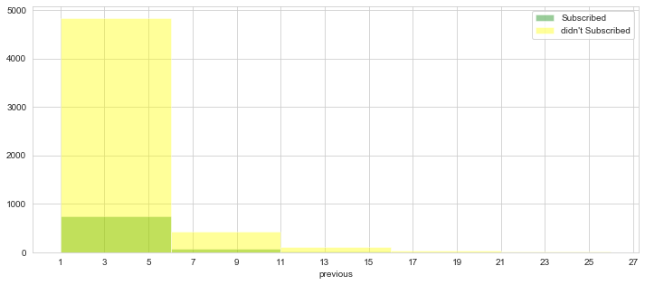

```python
fig = plt.figure(figsize=(12, 5))

modified_data= data.loc[data['previous'] <30 ]
modified_data= modified_data.loc[modified_data['previous'] >0 ]

maxx = int(max(modified_data['previous']))
minn = int(min(modified_data['previous']))
bins = range(minn,maxx, 5)
sns.set_style('whitegrid')
ax = sns.distplot(modified_data.previous[data['class']=='yes'],
               color='green',  bins=bins,kde = False, label='Subscribed')
sns.distplot(modified_data.previous[data['class']=='no'],
         ax=ax,color='yellow',kde = False, bins=bins, label="didn't Subscribed")

plt.xticks([x for x in range(minn,maxx,2)])
plt.legend()
plt.show()
```

Again, we can see a definite trend, which applies that if a costumer didn't subscribe in the first number of contacts that performed before this campaign, he also won't subscribe later.

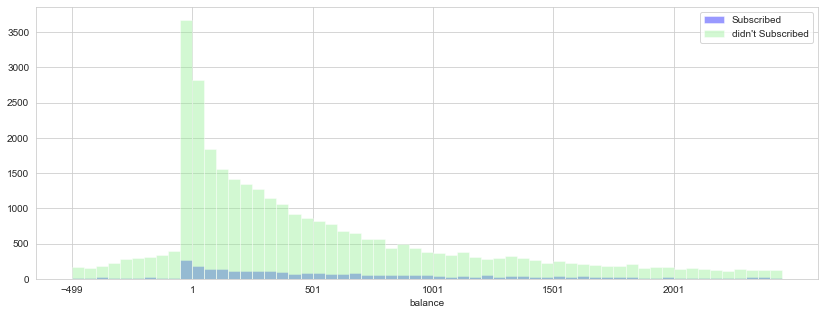

```python
fig = plt.figure(figsize=(14, 5))


modified_data= data.loc[data['balance'] <5000 ]
modified_data= modified_data.loc[modified_data['balance'] >-500 ]
maxx = int(max(modified_data['balance'])/2)
minn = int(min(modified_data['balance']))
bins = range(minn,maxx, 50)

sns.set_style('whitegrid')
ax = sns.distplot(modified_data.balance[data['class']=='yes'],
               color='blue',  bins=bins,kde = False, label='Subscribed')
sns.distplot(data.balance[data['class']=='no'],
         ax=ax,color='lightgreen',kde = False, bins=bins, label="didn't Subscribed")
plt.xticks([x for x in range(minn,maxx,500)])

plt.legend()
plt.show()
```

Here we chose to focus somewhere around the 25% of the mean - because we could identify an interesting trend.  
people with just a little bit above zero tend to be more aware to the concept of term deposit. Also, the higher the balance of an indevidual - the lower the chance he will subscribe.

## Our conclusions

as we mentioned earlier, the dataset comes with a Negligible amount of missing data, which allowed us to either remove entire wors with missing data, or choosing the most common values to replace the missing data (plots and anlysis in the other files of the project). The data set is not balanced, with a significant difference between the amount of 'Yes' and 'No' in the classification column. therefore, we had a very little success based on the test file. we did have an impressive success on the splitted tol 80 / 20 train file (more then 90%) which indicated that we were doing a fine job (all the results and Comparisons can be viewed in the other file).